# Overview

Quantile statistics

| Minimum | 0 |
| --- | --- |
| 5-th percentile | 0 |
| Q1 | 0 |
| Median | 0 |
| Q3 | 0.003906 |
| 95-th percentile | 0.030957 |
| Maximum | 0.076172 |
| Range | 0.076172 |
| Interquartile range | 0.003906 |

Descriptive statistics

| Standard deviation | 0.010509 |
| --- | --- |
| Coef of variation | 2.1013 |
| Kurtosis | 9.8936 |
| Mean | 0.0050011 |
| MAD | 0.0065433 |
| Skewness | 3.051 |
| Sum | 7.9218 |
| Variance | 0.00011044 |
| Memory size | 12.5 KiB |

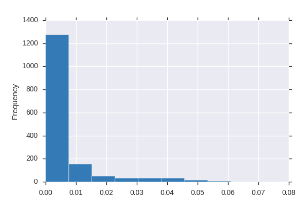

margin63  
Numeric

| Distinct count | 54 |
| --- | --- |
| Unique (%) | 3.4% |
| Missing (%) | 0.0% |
| Missing (n) | 0 |
| Infinite (%) | 0.0% |
| Infinite (n) | 0 |

| Mean | 0.025326 |
| --- | --- |
| Minimum | 0 |
| Maximum | 0.125 |
| Zeros (%) | 6.0% |

Toggle details

Quantile statistics

| Minimum | 0 |
| --- | --- |
| 5-th percentile | 0 |
| Q1 | 0.009766 |
| Median | 0.021484 |
| Q3 | 0.037109 |
| 95-th percentile | 0.0625 |
| Maximum | 0.125 |
| Range | 0.125 |
| Interquartile range | 0.027343 |

Descriptive statistics

| Standard deviation | 0.019788 |
| --- | --- |
| Coef of variation | 0.78133 |
| Kurtosis | 0.79189 |
| Mean | 0.025326 |
| MAD | 0.016028 |
| Skewness | 0.8974 |
| Sum | 40.117 |
| Variance | 0.00039157 |
| Memory size | 12.5 KiB |

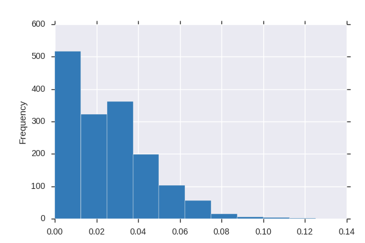

margin64  
Numeric

| Distinct count | 34 |
| --- | --- |
| Unique (%) | 2.1% |
| Missing (%) | 0.0% |
| Missing (n) | 0 |
| Infinite (%) | 0.0% |
| Infinite (n) | 0 |

| Mean | 0.0041972 |
| --- | --- |
| Minimum | 0 |
| Maximum | 0.089844 |
| Zeros (%) | 44.1% |

Toggle details

Quantile statistics

| Minimum | 0 |
| --- | --- |
| 5-th percentile | 0 |
| Q1 | 0 |
| Median | 0.001953 |
| Q3 | 0.003906 |
| 95-th percentile | 0.019531 |
| Maximum | 0.089844 |
| Range | 0.089844 |
| Interquartile range | 0.003906 |

Descriptive statistics

| Standard deviation | 0.0088586 |
| --- | --- |
| Coef of variation | 2.1106 |
| Kurtosis | 27.248 |
| Mean | 0.0041972 |
| MAD | 0.0048756 |
| Skewness | 4.5452 |
| Sum | 6.6483 |
| Variance | 7.8475e-05 |
| Memory size | 12.5 KiB |

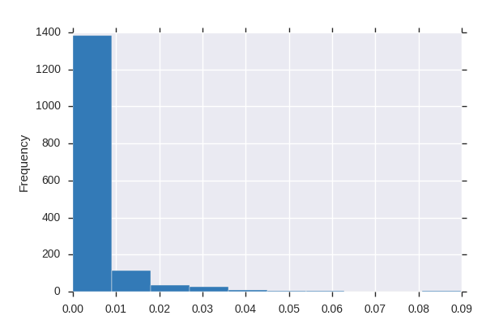

margin7  
Numeric

| Distinct count | 46 |
| --- | --- |
| Unique (%) | 2.9% |
| Missing (%) | 0.0% |
| Missing (n) | 0 |
| Infinite (%) | 0.0% |
| Infinite (n) | 0 |

| Mean | 0.019209 |
| --- | --- |
| Minimum | 0 |
| Maximum | 0.091797 |
| Zeros (%) | 13.0% |

Toggle details

Quantile statistics

| Minimum | 0 |
| --- | --- |
| 5-th percentile | 0 |
| Q1 | 0.005859 |
| Median | 0.015625 |
| Q3 | 0.029297 |
| 95-th percentile | 0.054688 |
| Maximum | 0.091797 |
| Range | 0.091797 |
| Interquartile range | 0.023438 |

Descriptive statistics

| Standard deviation | 0.017361 |
| --- | --- |
| Coef of variation | 0.90376 |
| Kurtosis | 1.2148 |
| Mean | 0.019209 |
| MAD | 0.013692 |
| Skewness | 1.156 |
| Sum | 30.428 |
| Variance | 0.00030139 |
| Memory size | 12.5 KiB |

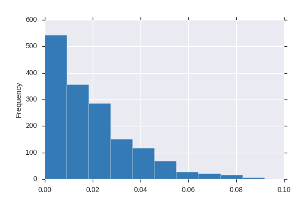

margin8  
Numeric

| Distinct count | 13 |
| --- | --- |
| Unique (%) | 0.8% |
| Missing (%) | 0.0% |
| Missing (n) | 0 |
| Infinite (%) | 0.0% |
| Infinite (n) | 0 |

| Mean | 0.0010838 |
| --- | --- |
| Minimum | 0 |
| Maximum | 0.03125 |
| Zeros (%) | 81.4% |

Toggle details

Quantile statistics

| Minimum | 0 |
| --- | --- |
| 5-th percentile | 0 |
| Q1 | 0 |
| Median | 0 |
| Q3 | 0 |
| 95-th percentile | 0.005859 |
| Maximum | 0.03125 |
| Range | 0.03125 |
| Interquartile range | 0 |

Descriptive statistics

| Standard deviation | 0.0027248 |
| --- | --- |
| Coef of variation | 2.5142 |
| Kurtosis | 27.908 |
| Mean | 0.0010838 |
| MAD | 0.0017652 |
| Skewness | 4.1012 |
| Sum | 1.7167 |
| Variance | 7.4245e-06 |
| Memory size | 12.5 KiB |

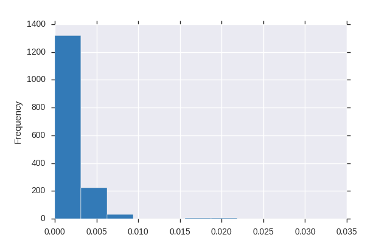

margin9  
Numeric

| Distinct count | 34 |
| --- | --- |
| Unique (%) | 2.1% |
| Missing (%) | 0.0% |
| Missing (n) | 0 |
| Infinite (%) | 0.0% |
| Infinite (n) | 0 |

| Mean | 0.0071391 |
| --- | --- |
| Minimum | 0 |
| Maximum | 0.083984 |
| Zeros (%) | 24.1% |

Toggle details

Quantile statistics

| Minimum | 0 |
| --- | --- |
| 5-th percentile | 0 |
| Q1 | 0.001953 |
| Median | 0.005859 |
| Q3 | 0.007812 |
| 95-th percentile | 0.023438 |
| Maximum | 0.083984 |
| Range | 0.083984 |
| Interquartile range | 0.005859 |

Descriptive statistics

| Standard deviation | 0.0091526 |
| --- | --- |
| Coef of variation | 1.282 |
| Kurtosis | 14.115 |
| Mean | 0.0071391 |
| MAD | 0.0054706 |
| Skewness | 3.2429 |
| Sum | 11.308 |
| Variance | 8.3769e-05 |
| Memory size | 12.5 KiB |

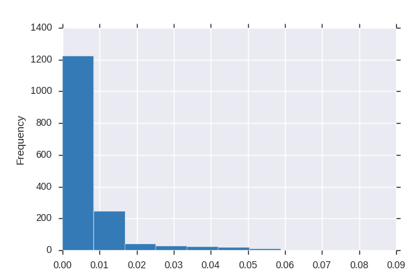

shape1  
Numeric

| Distinct count | 1563 |
| --- | --- |
| Unique (%) | 98.7% |
| Missing (%) | 0.0% |
| Missing (n) | 0 |
| Infinite (%) | 0.0% |
| Infinite (n) | 0 |

| Mean | 0.0007375 |
| --- | --- |
| Minimum | 0.00016798 |
| Maximum | 0.0023897 |
| Zeros (%) | 0.0% |

Toggle details

Quantile statistics

| Minimum | 0.00016798 |
| --- | --- |
| 5-th percentile | 0.00036053 |
| Q1 | 0.00051869 |
| Median | 0.00071114 |
| Q3 | 0.00092842 |
| 95-th percentile | 0.0011937 |
| Maximum | 0.0023897 |
| Range | 0.0022217 |
| Interquartile range | 0.00040973 |

Descriptive statistics

| Standard deviation | 0.00027048 |
| --- | --- |
| Coef of variation | 0.36675 |
| Kurtosis | 0.73297 |
| Mean | 0.0007375 |
| MAD | 0.00022203 |
| Skewness | 0.5969 |
| Sum | 1.1682 |
| Variance | 7.3158e-08 |
| Memory size | 12.5 KiB |

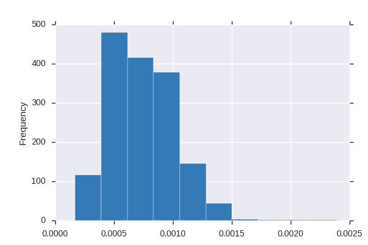

Highly correlated

*This variable is highly correlated with `shape9` and should be ignored for analysis*

| Correlation | 0.99007 |
| --- | --- |

Highly correlated

*This variable is highly correlated with `shape10` and should be ignored for analysis*

| Correlation | 0.99183 |
| --- | --- |

Highly correlated

*This variable is highly correlated with `shape11` and should be ignored for analysis*

| Correlation | 0.99227 |
| --- | --- |

Highly correlated

*This variable is highly correlated with `shape12` and should be ignored for analysis*

| Correlation | 0.99288 |
| --- | --- |

Highly correlated

*This variable is highly correlated with `shape13` and should be ignored for analysis*

| Correlation | 0.99259 |
| --- | --- |

Highly correlated

*This variable is highly correlated with `shape14` and should be ignored for analysis*

| Correlation | 0.99354 |
| --- | --- |

Highly correlated

*This variable is highly correlated with `shape15` and should be ignored for analysis*

| Correlation | 0.9937 |
| --- | --- |

Highly correlated

*This variable is highly correlated with `shape16` and should be ignored for analysis*

| Correlation | 0.99364 |
| --- | --- |

Highly correlated

*This variable is highly correlated with `shape17` and should be ignored for analysis*

| Correlation | 0.99395 |
| --- | --- |

Highly correlated

*This variable is highly correlated with `shape18` and should be ignored for analysis*

| Correlation | 0.99376 |
| --- | --- |

Highly correlated

*This variable is highly correlated with `shape1` and should be ignored for analysis*

| Correlation | 0.98852 |
| --- | --- |

Highly correlated

*This variable is highly correlated with `shape19` and should be ignored for analysis*

| Correlation | 0.99384 |
| --- | --- |

Highly correlated

*This variable is highly correlated with `shape20` and should be ignored for analysis*

| Correlation | 0.99388 |
| --- | --- |

Highly correlated

*This variable is highly correlated with `shape21` and should be ignored for analysis*

| Correlation | 0.99311 |
| --- | --- |

Highly correlated

*This variable is highly correlated with `shape22` and should be ignored for analysis*

| Correlation | 0.99215 |
| --- | --- |

Highly correlated

*This variable is highly correlated with `shape23` and should be ignored for analysis*

| Correlation | 0.99051 |
| --- | --- |

Highly correlated

*This variable is highly correlated with `shape24` and should be ignored for analysis*

| Correlation | 0.98878 |
| --- | --- |

Highly correlated

*This variable is highly correlated with `shape25` and should be ignored for analysis*

| Correlation | 0.98709 |
| --- | --- |

Highly correlated

*This variable is highly correlated with `shape26` and should be ignored for analysis*

| Correlation | 0.98444 |
| --- | --- |

Highly correlated

*This variable is highly correlated with `shape27` and should be ignored for analysis*

| Correlation | 0.98378 |
| --- | --- |

Highly correlated

*This variable is highly correlated with `shape28` and should be ignored for analysis*

| Correlation | 0.98383 |
| --- | --- |

Highly correlated

*This variable is highly correlated with `shape2` and should be ignored for analysis*

| Correlation | 0.98944 |
| --- | --- |

Highly correlated

*This variable is highly correlated with `shape29` and should be ignored for analysis*

| Correlation | 0.98519 |
| --- | --- |

Highly correlated

*This variable is highly correlated with `shape30` and should be ignored for analysis*

| Correlation | 0.98721 |
| --- | --- |

Highly correlated

*This variable is highly correlated with `shape31` and should be ignored for analysis*

| Correlation | 0.98764 |
| --- | --- |

Highly correlated

*This variable is highly correlated with `shape32` and should be ignored for analysis*

| Correlation | 0.98782 |
| --- | --- |

Highly correlated

*This variable is highly correlated with `shape33` and should be ignored for analysis*

| Correlation | 0.98855 |
| --- | --- |

Highly correlated

*This variable is highly correlated with `shape34` and should be ignored for analysis*

| Correlation | 0.98851 |
| --- | --- |

Highly correlated

*This variable is highly correlated with `shape35` and should be ignored for analysis*

| Correlation | 0.98677 |
| --- | --- |

Highly correlated

*This variable is highly correlated with `shape36` and should be ignored for analysis*

| Correlation | 0.98519 |
| --- | --- |

Highly correlated

*This variable is highly correlated with `shape37` and should be ignored for analysis*

| Correlation | 0.98332 |
| --- | --- |

Highly correlated

*This variable is highly correlated with `shape38` and should be ignored for analysis*

| Correlation | 0.98287 |
| --- | --- |

Highly correlated

*This variable is highly correlated with `shape3` and should be ignored for analysis*

| Correlation | 0.98872 |
| --- | --- |

Highly correlated

*This variable is highly correlated with `shape39` and should be ignored for analysis*

| Correlation | 0.98363 |
| --- | --- |

Highly correlated

*This variable is highly correlated with `shape40` and should be ignored for analysis*

| Correlation | 0.98575 |
| --- | --- |

Highly correlated

*This variable is highly correlated with `shape41` and should be ignored for analysis*

| Correlation | 0.98734 |
| --- | --- |

Highly correlated

*This variable is highly correlated with `shape42` and should be ignored for analysis*

| Correlation | 0.98969 |
| --- | --- |

Highly correlated

*This variable is highly correlated with `shape43` and should be ignored for analysis*

| Correlation | 0.99047 |
| --- | --- |

Highly correlated

*This variable is highly correlated with `shape44` and should be ignored for analysis*

| Correlation | 0.99148 |
| --- | --- |

Highly correlated

*This variable is highly correlated with `shape45` and should be ignored for analysis*

| Correlation | 0.99202 |
| --- | --- |

Highly correlated

*This variable is highly correlated with `shape46` and should be ignored for analysis*

| Correlation | 0.99304 |
| --- | --- |

Highly correlated

*This variable is highly correlated with `shape47` and should be ignored for analysis*

| Correlation | 0.99327 |
| --- | --- |

Highly correlated

*This variable is highly correlated with `shape48` and should be ignored for analysis*

| Correlation | 0.99356 |
| --- | --- |

Highly correlated

*This variable is highly correlated with `shape4` and should be ignored for analysis*

| Correlation | 0.98764 |
| --- | --- |

Highly correlated

*This variable is highly correlated with `shape49` and should be ignored for analysis*

| Correlation | 0.9938 |
| --- | --- |

Highly correlated

*This variable is highly correlated with `shape50` and should be ignored for analysis*

| Correlation | 0.99348 |
| --- | --- |

Highly correlated

*This variable is highly correlated with `shape51` and should be ignored for analysis*

| Correlation | 0.99297 |
| --- | --- |

Highly correlated

*This variable is highly correlated with `shape52` and should be ignored for analysis*

| Correlation | 0.99295 |
| --- | --- |

Highly correlated

*This variable is highly correlated with `shape53` and should be ignored for analysis*

| Correlation | 0.99139 |
| --- | --- |

Highly correlated

*This variable is highly correlated with `shape54` and should be ignored for analysis*

| Correlation | 0.98986 |
| --- | --- |

Highly correlated

*This variable is highly correlated with `shape55` and should be ignored for analysis*

| Correlation | 0.98811 |
| --- | --- |

Highly correlated

*This variable is highly correlated with `shape56` and should be ignored for analysis*

| Correlation | 0.98611 |
| --- | --- |

Highly correlated

*This variable is highly correlated with `shape57` and should be ignored for analysis*

| Correlation | 0.98469 |
| --- | --- |

Highly correlated

*This variable is highly correlated with `shape58` and should be ignored for analysis*

| Correlation | 0.98386 |
| --- | --- |

Highly correlated

*This variable is highly correlated with `shape5` and should be ignored for analysis*

| Correlation | 0.98633 |
| --- | --- |

Highly correlated

*This variable is highly correlated with `shape59` and should be ignored for analysis*

| Correlation | 0.98381 |
| --- | --- |

Highly correlated

*This variable is highly correlated with `shape60` and should be ignored for analysis*

| Correlation | 0.98495 |
| --- | --- |

Highly correlated

*This variable is highly correlated with `shape61` and should be ignored for analysis*

| Correlation | 0.98726 |
| --- | --- |

Highly correlated

*This variable is highly correlated with `shape62` and should be ignored for analysis*

| Correlation | 0.9881 |
| --- | --- |

Highly correlated

*This variable is highly correlated with `shape63` and should be ignored for analysis*

| Correlation | 0.98858 |
| --- | --- |

Highly correlated

*This variable is highly correlated with `shape6` and should be ignored for analysis*

| Correlation | 0.98523 |
| --- | --- |

Highly correlated

*This variable is highly correlated with `shape7` and should be ignored for analysis*

| Correlation | 0.98647 |
| --- | --- |

Highly correlated

*This variable is highly correlated with `shape8` and should be ignored for analysis*

| Correlation | 0.98851 |
| --- | --- |

texture1  
Numeric

| Distinct count | 151 |
| --- | --- |
| Unique (%) | 9.5% |
| Missing (%) | 0.0% |
| Missing (n) | 0 |
| Infinite (%) | 0.0% |
| Infinite (n) | 0 |

| Mean | 0.021278 |
| --- | --- |
| Minimum | 0 |
| Maximum | 0.41309 |
| Zeros (%) | 25.8% |

Toggle details

Quantile statistics

| Minimum | 0 |
| --- | --- |
| 5-th percentile | 0 |
| Q1 | 0 |
| Median | 0.006836 |
| Q3 | 0.021484 |
| 95-th percentile | 0.095703 |
| Maximum | 0.41309 |
| Range | 0.41309 |
| Interquartile range | 0.021484 |

Descriptive statistics

| Standard deviation | 0.041271 |
| --- | --- |
| Coef of variation | 1.9396 |
| Kurtosis | 29.781 |
| Mean | 0.021278 |
| MAD | 0.023702 |
| Skewness | 4.5826 |
| Sum | 33.704 |
| Variance | 0.0017033 |
| Memory size | 12.5 KiB |

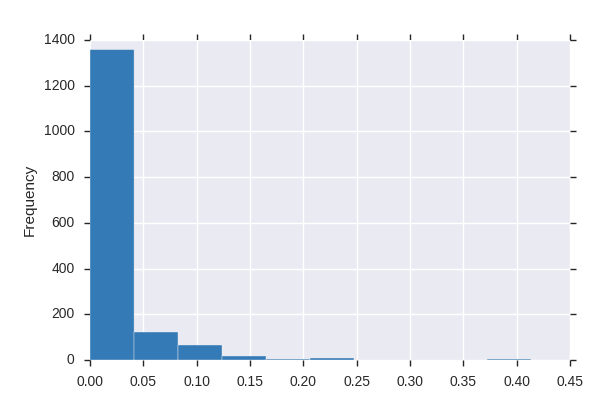

texture10  
Numeric

| Distinct count | 146 |
| --- | --- |
| Unique (%) | 9.2% |
| Missing (%) | 0.0% |
| Missing (n) | 0 |
| Infinite (%) | 0.0% |
| Infinite (n) | 0 |

| Mean | 0.019903 |
| --- | --- |
| Minimum | 0 |
| Maximum | 0.31543 |
| Zeros (%) | 35.0% |

Toggle details

Quantile statistics

| Minimum | 0 |
| --- | --- |
| 5-th percentile | 0 |
| Q1 | 0 |
| Median | 0.003906 |
| Q3 | 0.022461 |
| 95-th percentile | 0.095703 |
| Maximum | 0.31543 |
| Range | 0.31543 |
| Interquartile range | 0.022461 |

Descriptive statistics

| Standard deviation | 0.037194 |
| --- | --- |
| Coef of variation | 1.8688 |
| Kurtosis | 13.83 |
| Mean | 0.019903 |
| MAD | 0.023863 |
| Skewness | 3.269 |
| Sum | 31.526 |
| Variance | 0.0013834 |
| Memory size | 12.5 KiB |

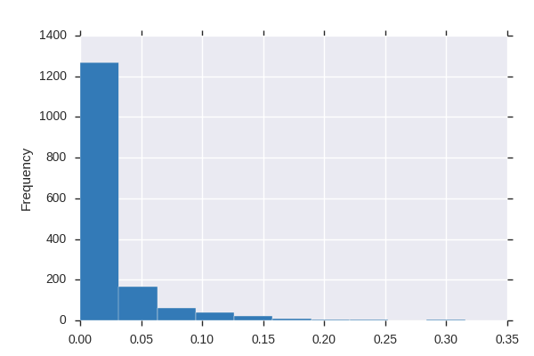

texture11  
Numeric

| Distinct count | 140 |
| --- | --- |
| Unique (%) | 8.8% |
| Missing (%) | 0.0% |
| Missing (n) | 0 |
| Infinite (%) | 0.0% |
| Infinite (n) | 0 |

| Mean | 0.019488 |
| --- | --- |
| Minimum | 0 |
| Maximum | 0.28516 |
| Zeros (%) | 36.2% |

Toggle details

Quantile statistics

| Minimum | 0 |
| --- | --- |
| 5-th percentile | 0 |
| Q1 | 0 |
| Median | 0.003906 |
| Q3 | 0.025391 |
| 95-th percentile | 0.088721 |
| Maximum | 0.28516 |
| Range | 0.28516 |
| Interquartile range | 0.025391 |

Descriptive statistics

| Standard deviation | 0.034377 |
| --- | --- |
| Coef of variation | 1.764 |
| Kurtosis | 11.732 |
| Mean | 0.019488 |
| MAD | 0.023206 |
| Skewness | 2.981 |
| Sum | 30.869 |
| Variance | 0.0011818 |
| Memory size | 12.5 KiB |

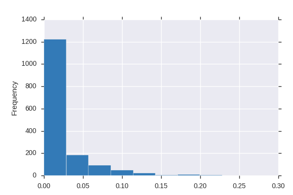

texture12  
Numeric

| Distinct count | 187 |
| --- | --- |
| Unique (%) | 11.8% |
| Missing (%) | 0.0% |
| Missing (n) | 0 |
| Infinite (%) | 0.0% |
| Infinite (n) | 0 |

| Mean | 0.026033 |
| --- | --- |
| Minimum | 0 |
| Maximum | 0.50781 |
| Zeros (%) | 65.9% |

Toggle details

Quantile statistics

| Minimum | 0 |
| --- | --- |
| 5-th percentile | 0 |
| Q1 | 0 |
| Median | 0 |
| Q3 | 0.006836 |
| 95-th percentile | 0.17758 |
| Maximum | 0.50781 |
| Range | 0.50781 |
| Interquartile range | 0.006836 |

Descriptive statistics

| Standard deviation | 0.072149 |
| --- | --- |
| Coef of variation | 2.7714 |
| Kurtosis | 13.748 |
| Mean | 0.026033 |
| MAD | 0.040203 |
| Skewness | 3.6516 |
| Sum | 41.236 |
| Variance | 0.0052055 |
| Memory size | 12.5 KiB |

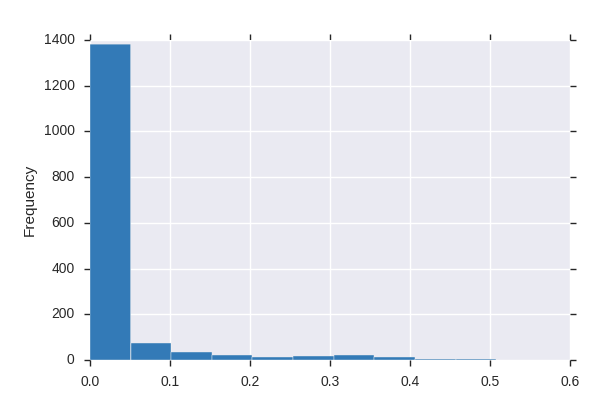

texture13  
Numeric

| Distinct count | 76 |
| --- | --- |
| Unique (%) | 4.8% |
| Missing (%) | 0.0% |
| Missing (n) | 0 |
| Infinite (%) | 0.0% |
| Infinite (n) | 0 |

| Mean | 0.0098125 |
| --- | --- |
| Minimum | 0 |
| Maximum | 0.11133 |
| Zeros (%) | 30.5% |

Toggle details

Quantile statistics

| Minimum | 0 |
| --- | --- |
| 5-th percentile | 0 |
| Q1 | 0 |
| Median | 0.004883 |
| Q3 | 0.014648 |
| 95-th percentile | 0.035156 |
| Maximum | 0.11133 |
| Range | 0.11133 |
| Interquartile range | 0.014648 |

Descriptive statistics

| Standard deviation | 0.014391 |
| --- | --- |
| Coef of variation | 1.4666 |
| Kurtosis | 13.44 |
| Mean | 0.0098125 |
| MAD | 0.0097979 |
| Skewness | 3.0304 |
| Sum | 15.543 |
| Variance | 0.00020711 |
| Memory size | 12.5 KiB |

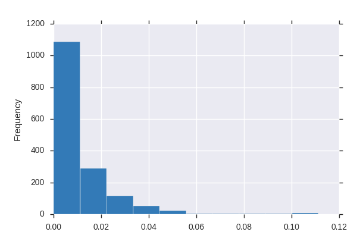

texture14  
Numeric

| Distinct count | 91 |
| --- | --- |
| Unique (%) | 5.7% |
| Missing (%) | 0.0% |
| Missing (n) | 0 |
| Infinite (%) | 0.0% |
| Infinite (n) | 0 |

| Mean | 0.01297 |
| --- | --- |
| Minimum | 0 |
| Maximum | 0.18457 |
| Zeros (%) | 31.9% |

Toggle details

Quantile statistics

| Minimum | 0 |
| --- | --- |
| 5-th percentile | 0 |
| Q1 | 0 |
| Median | 0.006836 |
| Q3 | 0.018799 |
| 95-th percentile | 0.045752 |
| Maximum | 0.18457 |
| Range | 0.18457 |
| Interquartile range | 0.018799 |

Descriptive statistics

| Standard deviation | 0.018048 |
| --- | --- |
| Coef of variation | 1.3915 |
| Kurtosis | 13.445 |
| Mean | 0.01297 |
| MAD | 0.012578 |
| Skewness | 2.8483 |
| Sum | 20.545 |
| Variance | 0.00032575 |
| Memory size | 12.5 KiB |

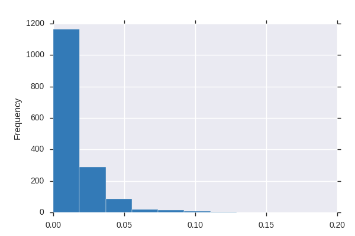

texture15  
Numeric

| Distinct count | 104 |
| --- | --- |
| Unique (%) | 6.6% |
| Missing (%) | 0.0% |
| Missing (n) | 0 |
| Infinite (%) | 0.0% |
| Infinite (n) | 0 |

| Mean | 0.012841 |
| --- | --- |
| Minimum | 0 |
| Maximum | 0.85352 |
| Zeros (%) | 81.3% |

Toggle details

Quantile statistics

| Minimum | 0 |
| --- | --- |
| 5-th percentile | 0 |
| Q1 | 0 |
| Median | 0 |
| Q3 | 0 |
| 95-th percentile | 0.039892 |
| Maximum | 0.85352 |
| Range | 0.85352 |
| Interquartile range | 0 |

Descriptive statistics

| Standard deviation | 0.070141 |
| --- | --- |
| Coef of variation | 5.4623 |
| Kurtosis | 67.837 |
| Mean | 0.012841 |
| MAD | 0.022745 |
| Skewness | 7.8442 |
| Sum | 20.34 |
| Variance | 0.0049197 |
| Memory size | 12.5 KiB |

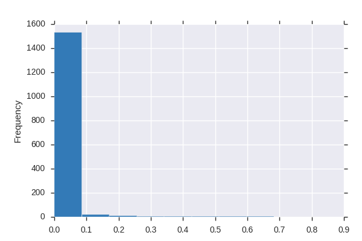

texture16  
Numeric

| Distinct count | 63 |
| --- | --- |
| Unique (%) | 4.0% |
| Missing (%) | 0.0% |
| Missing (n) | 0 |
| Infinite (%) | 0.0% |
| Infinite (n) | 0 |

| Mean | 0.0049235 |
| --- | --- |
| Minimum | 0 |
| Maximum | 0.11914 |
| Zeros (%) | 68.8% |

Toggle details

Quantile statistics

| Minimum | 0 |
| --- | --- |
| 5-th percentile | 0 |
| Q1 | 0 |
| Median | 0 |
| Q3 | 0.00293 |
| 95-th percentile | 0.02832 |
| Maximum | 0.11914 |
| Range | 0.11914 |
| Interquartile range | 0.00293 |

Descriptive statistics

| Standard deviation | 0.012493 |
| --- | --- |
| Coef of variation | 2.5375 |
| Kurtosis | 26.69 |
| Mean | 0.0049235 |
| MAD | 0.0072389 |
| Skewness | 4.4812 |
| Sum | 7.7988 |
| Variance | 0.00015608 |
| Memory size | 12.5 KiB |

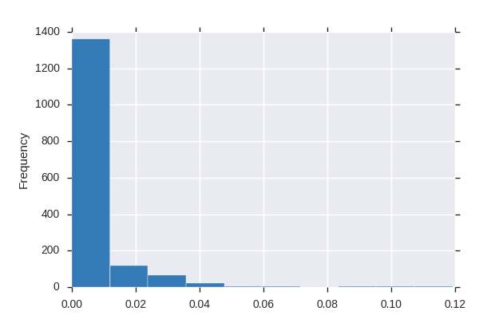

texture17  
Numeric

| Distinct count | 116 |
| --- | --- |
| Unique (%) | 7.3% |
| Missing (%) | 0.0% |
| Missing (n) | 0 |
| Infinite (%) | 0.0% |
| Infinite (n) | 0 |

| Mean | 0.014468 |
| --- | --- |
| Minimum | 0 |
| Maximum | 0.30566 |
| Zeros (%) | 29.7% |

Toggle details

Quantile statistics

| Minimum | 0 |
| --- | --- |
| 5-th percentile | 0 |
| Q1 | 0 |
| Median | 0.003906 |
| Q3 | 0.017578 |
| 95-th percentile | 0.064307 |
| Maximum | 0.30566 |
| Range | 0.30566 |
| Interquartile range | 0.017578 |

Descriptive statistics

| Standard deviation | 0.026239 |
| --- | --- |
| Coef of variation | 1.8135 |
| Kurtosis | 19.86 |
| Mean | 0.014468 |
| MAD | 0.016305 |
| Skewness | 3.6887 |
| Sum | 22.918 |
| Variance | 0.00068847 |
| Memory size | 12.5 KiB |

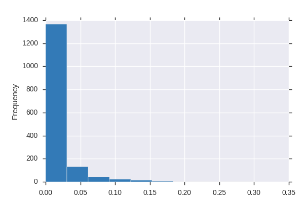

texture18  
Numeric

| Distinct count | 73 |
| --- | --- |
| Unique (%) | 4.6% |
| Missing (%) | 0.0% |
| Missing (n) | 0 |
| Infinite (%) | 0.0% |
| Infinite (n) | 0 |

| Mean | 0.0058502 |
| --- | --- |
| Minimum | 0 |
| Maximum | 0.20898 |
| Zeros (%) | 49.6% |

Toggle details

Quantile statistics

| Minimum | 0 |
| --- | --- |
| 5-th percentile | 0 |
| Q1 | 0 |
| Median | 0.000977 |
| Q3 | 0.004883 |
| 95-th percentile | 0.030273 |
| Maximum | 0.20898 |
| Range | 0.20898 |
| Interquartile range | 0.004883 |

Descriptive statistics

| Standard deviation | 0.013682 |
| --- | --- |
| Coef of variation | 2.3388 |
| Kurtosis | 43.628 |
| Mean | 0.0058502 |
| MAD | 0.0076985 |
| Skewness | 5.1094 |
| Sum | 9.2666 |
| Variance | 0.00018721 |
| Memory size | 12.5 KiB |

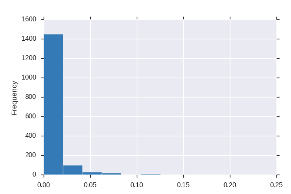

texture19  
Numeric

| Distinct count | 134 |
| --- | --- |
| Unique (%) | 8.5% |
| Missing (%) | 0.0% |
| Missing (n) | 0 |
| Infinite (%) | 0.0% |
| Infinite (n) | 0 |

| Mean | 0.024534 |
| --- | --- |
| Minimum | 0 |
| Maximum | 0.30078 |
| Zeros (%) | 16.4% |

Toggle details

Quantile statistics

| Minimum | 0 |
| --- | --- |
| 5-th percentile | 0 |
| Q1 | 0.00293 |
| Median | 0.013672 |
| Q3 | 0.036133 |
| 95-th percentile | 0.079102 |
| Maximum | 0.30078 |
| Range | 0.30078 |
| Interquartile range | 0.033203 |

Descriptive statistics

| Standard deviation | 0.03154 |
| --- | --- |
| Coef of variation | 1.2856 |
| Kurtosis | 12.776 |
| Mean | 0.024534 |
| MAD | 0.022041 |
| Skewness | 2.8121 |
| Sum | 38.861 |
| Variance | 0.0009948 |
| Memory size | 12.5 KiB |

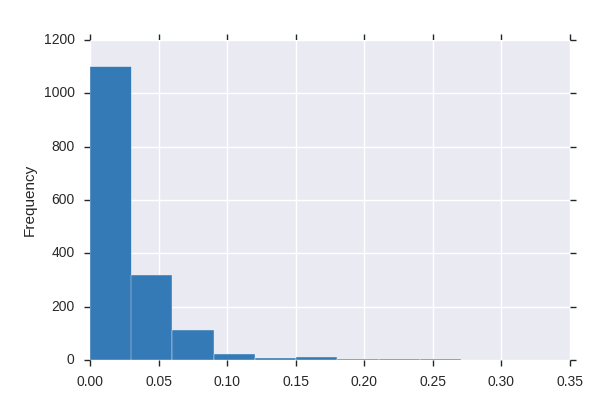

texture2  
Numeric

| Distinct count | 91 |
| --- | --- |
| Unique (%) | 5.7% |
| Missing (%) | 0.0% |
| Missing (n) | 0 |
| Infinite (%) | 0.0% |
| Infinite (n) | 0 |

| Mean | 0.011666 |
| --- | --- |
| Minimum | 0 |
| Maximum | 0.14746 |
| Zeros (%) | 19.1% |

Toggle details

Quantile statistics

| Minimum | 0 |
| --- | --- |
| 5-th percentile | 0 |
| Q1 | 0.000977 |
| Median | 0.004883 |
| Q3 | 0.014648 |
| 95-th percentile | 0.048828 |
| Maximum | 0.14746 |
| Range | 0.14746 |
| Interquartile range | 0.013671 |

Descriptive statistics

| Standard deviation | 0.017611 |
| --- | --- |
| Coef of variation | 1.5096 |
| Kurtosis | 9.9559 |
| Mean | 0.011666 |
| MAD | 0.011779 |
| Skewness | 2.7933 |
| Sum | 18.48 |
| Variance | 0.00031016 |
| Memory size | 12.5 KiB |

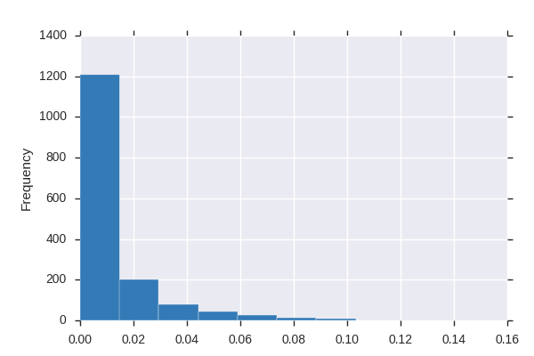

texture20  
Numeric

| Distinct count | 92 |
| --- | --- |
| Unique (%) | 5.8% |
| Missing (%) | 0.0% |
| Missing (n) | 0 |
| Infinite (%) | 0.0% |
| Infinite (n) | 0 |

| Mean | 0.014447 |
| --- | --- |
| Minimum | 0 |
| Maximum | 0.13477 |
| Zeros (%) | 16.1% |

Toggle details

Quantile statistics

| Minimum | 0 |
| --- | --- |
| 5-th percentile | 0 |
| Q1 | 0.00293 |
| Median | 0.008789 |
| Q3 | 0.020508 |
| 95-th percentile | 0.045898 |
| Maximum | 0.13477 |
| Range | 0.13477 |
| Interquartile range | 0.017578 |

Descriptive statistics

| Standard deviation | 0.016741 |
| --- | --- |
| Coef of variation | 1.1588 |
| Kurtosis | 7.434 |
| Mean | 0.014447 |
| MAD | 0.011923 |
| Skewness | 2.2847 |
| Sum | 22.884 |
| Variance | 0.00028027 |
| Memory size | 12.5 KiB |

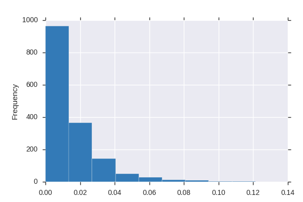

texture21  
Numeric

| Distinct count | 64 |
| --- | --- |
| Unique (%) | 4.0% |
| Missing (%) | 0.0% |
| Missing (n) | 0 |
| Infinite (%) | 0.0% |
| Infinite (n) | 0 |

| Mean | 0.002926 |
| --- | --- |
| Minimum | 0 |
| Maximum | 0.097656 |
| Zeros (%) | 84.8% |

Toggle details

Quantile statistics

| Minimum | 0 |
| --- | --- |
| 5-th percentile | 0 |
| Q1 | 0 |
| Median | 0 |
| Q3 | 0 |
| 95-th percentile | 0.021484 |
| Maximum | 0.097656 |
| Range | 0.097656 |
| Interquartile range | 0 |

Descriptive statistics

| Standard deviation | 0.010231 |
| --- | --- |
| Coef of variation | 3.4967 |
| Kurtosis | 25.135 |
| Mean | 0.002926 |
| MAD | 0.0050428 |
| Skewness | 4.6718 |
| Sum | 4.6348 |
| Variance | 0.00010468 |
| Memory size | 12.5 KiB |

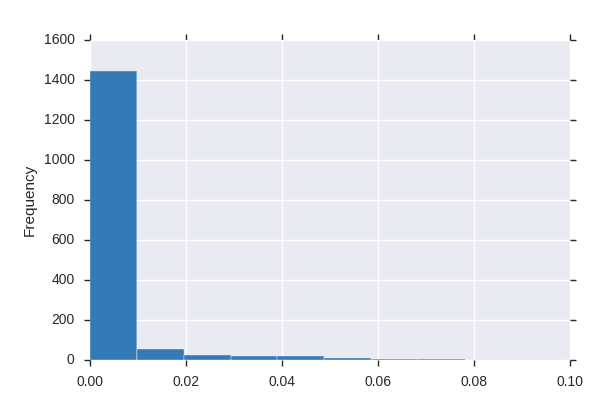

texture22  
Numeric

| Distinct count | 101 |
| --- | --- |
| Unique (%) | 6.4% |
| Missing (%) | 0.0% |
| Missing (n) | 0 |
| Infinite (%) | 0.0% |
| Infinite (n) | 0 |

| Mean | 0.01328 |
| --- | --- |
| Minimum | 0 |
| Maximum | 0.17773 |
| Zeros (%) | 39.4% |

Toggle details

Quantile statistics

| Minimum | 0 |
| --- | --- |
| 5-th percentile | 0 |
| Q1 | 0 |
| Median | 0.00293 |
| Q3 | 0.017578 |
| 95-th percentile | 0.059424 |
| Maximum | 0.17773 |
| Range | 0.17773 |
| Interquartile range | 0.017578 |

Descriptive statistics

| Standard deviation | 0.022108 |
| --- | --- |
| Coef of variation | 1.6648 |
| Kurtosis | 10.058 |
| Mean | 0.01328 |
| MAD | 0.015143 |
| Skewness | 2.766 |
| Sum | 21.035 |
| Variance | 0.00048875 |
| Memory size | 12.5 KiB |

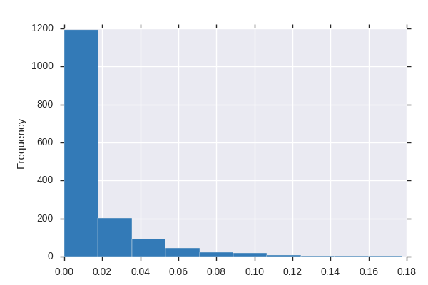

texture23  
Numeric

| Distinct count | 114 |
| --- | --- |
| Unique (%) | 7.2% |
| Missing (%) | 0.0% |
| Missing (n) | 0 |
| Infinite (%) | 0.0% |
| Infinite (n) | 0 |

| Mean | 0.016935 |
| --- | --- |
| Minimum | 0 |
| Maximum | 0.19531 |
| Zeros (%) | 16.2% |

Toggle details

Quantile statistics

| Minimum | 0 |
| --- | --- |
| 5-th percentile | 0 |
| Q1 | 0.001953 |
| Median | 0.006836 |
| Q3 | 0.022461 |
| 95-th percentile | 0.068213 |
| Maximum | 0.19531 |
| Range | 0.19531 |
| Interquartile range | 0.020508 |

Descriptive statistics

| Standard deviation | 0.023692 |
| --- | --- |
| Coef of variation | 1.399 |
| Kurtosis | 8.063 |
| Mean | 0.016935 |
| MAD | 0.016624 |
| Skewness | 2.4714 |
| Sum | 26.824 |
| Variance | 0.0005613 |
| Memory size | 12.5 KiB |

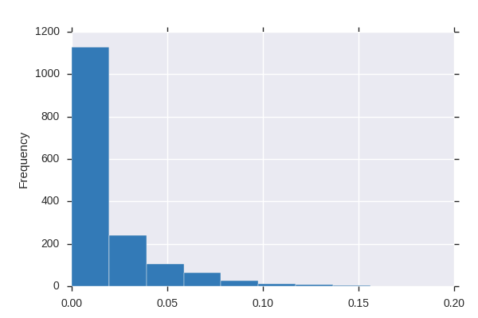

texture24  
Numeric

| Distinct count | 95 |
| --- | --- |
| Unique (%) | 6.0% |
| Missing (%) | 0.0% |
| Missing (n) | 0 |
| Infinite (%) | 0.0% |
| Infinite (n) | 0 |

| Mean | 0.010392 |
| --- | --- |
| Minimum | 0 |
| Maximum | 0.13477 |
| Zeros (%) | 35.8% |

Toggle details

Quantile statistics

| Minimum | 0 |
| --- | --- |
| 5-th percentile | 0 |
| Q1 | 0 |
| Median | 0.001953 |
| Q3 | 0.011719 |
| 95-th percentile | 0.050635 |
| Maximum | 0.13477 |
| Range | 0.13477 |
| Interquartile range | 0.011719 |

Descriptive statistics

| Standard deviation | 0.018254 |
| --- | --- |
| Coef of variation | 1.7565 |
| Kurtosis | 8.1136 |
| Mean | 0.010392 |
| MAD | 0.012403 |
| Skewness | 2.6546 |
| Sum | 16.461 |
| Variance | 0.00033321 |
| Memory size | 12.5 KiB |

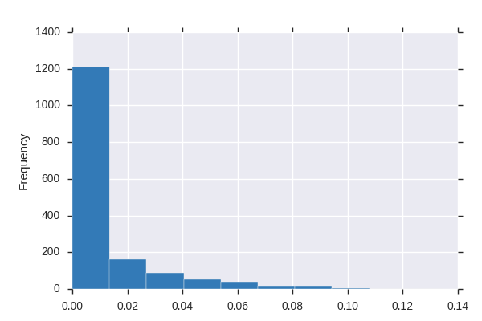

texture25  
Numeric

| Distinct count | 82 |
| --- | --- |
| Unique (%) | 5.2% |
| Missing (%) | 0.0% |
| Missing (n) | 0 |
| Infinite (%) | 0.0% |
| Infinite (n) | 0 |

| Mean | 0.010538 |
| --- | --- |
| Minimum | 0 |
| Maximum | 0.15332 |
| Zeros (%) | 28.3% |

Toggle details

Quantile statistics

| Minimum | 0 |
| --- | --- |
| 5-th percentile | 0 |
| Q1 | 0 |
| Median | 0.003906 |
| Q3 | 0.014648 |
| 95-th percentile | 0.040039 |
| Maximum | 0.15332 |
| Range | 0.15332 |
| Interquartile range | 0.014648 |

Descriptive statistics

| Standard deviation | 0.016008 |
| --- | --- |
| Coef of variation | 1.5191 |
| Kurtosis | 13.773 |
| Mean | 0.010538 |
| MAD | 0.010939 |
| Skewness | 2.9963 |
| Sum | 16.692 |
| Variance | 0.00025627 |
| Memory size | 12.5 KiB |

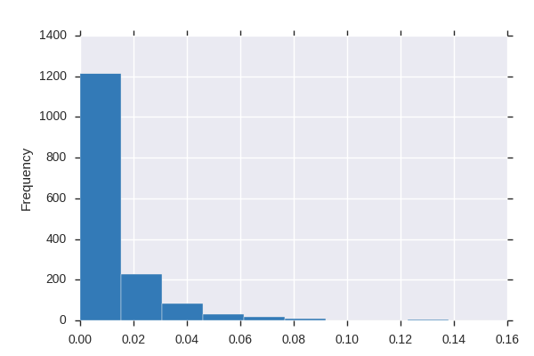

texture26  
Numeric

| Distinct count | 164 |
| --- | --- |
| Unique (%) | 10.4% |
| Missing (%) | 0.0% |
| Missing (n) | 0 |
| Infinite (%) | 0.0% |
| Infinite (n) | 0 |

| Mean | 0.023629 |
| --- | --- |
| Minimum | 0 |
| Maximum | 0.30273 |
| Zeros (%) | 33.1% |

Toggle details

Quantile statistics

| Minimum | 0 |
| --- | --- |
| 5-th percentile | 0 |
| Q1 | 0 |
| Median | 0.004883 |
| Q3 | 0.027588 |
| 95-th percentile | 0.11426 |
| Maximum | 0.30273 |
| Range | 0.30273 |
| Interquartile range | 0.027588 |

Descriptive statistics

| Standard deviation | 0.041997 |
| --- | --- |
| Coef of variation | 1.7773 |
| Kurtosis | 9.6635 |
| Mean | 0.023629 |
| MAD | 0.027989 |
| Skewness | 2.8502 |
| Sum | 37.429 |
| Variance | 0.0017638 |
| Memory size | 12.5 KiB |

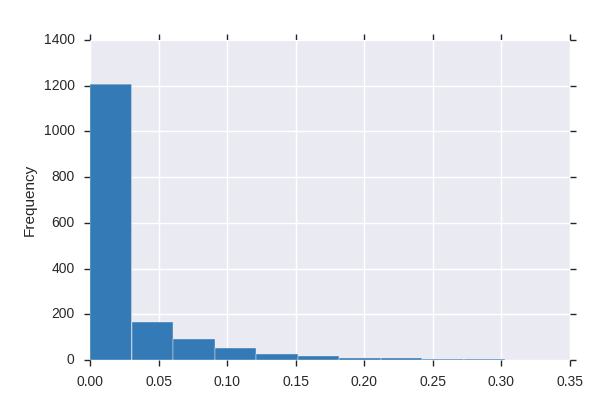

texture27  
Numeric

| Distinct count | 138 |
| --- | --- |
| Unique (%) | 8.7% |
| Missing (%) | 0.0% |
| Missing (n) | 0 |
| Infinite (%) | 0.0% |
| Infinite (n) | 0 |

| Mean | 0.021221 |
| --- | --- |
| Minimum | 0 |
| Maximum | 0.22754 |
| Zeros (%) | 30.6% |

Toggle details

Quantile statistics

| Minimum | 0 |
| --- | --- |
| 5-th percentile | 0 |
| Q1 | 0 |
| Median | 0.006836 |
| Q3 | 0.030273 |
| 95-th percentile | 0.092773 |
| Maximum | 0.22754 |
| Range | 0.22754 |
| Interquartile range | 0.030273 |

Descriptive statistics

| Standard deviation | 0.032144 |
| --- | --- |
| Coef of variation | 1.5148 |
| Kurtosis | 5.2378 |
| Mean | 0.021221 |
| MAD | 0.023413 |
| Skewness | 2.1672 |
| Sum | 33.613 |
| Variance | 0.0010332 |
| Memory size | 12.5 KiB |

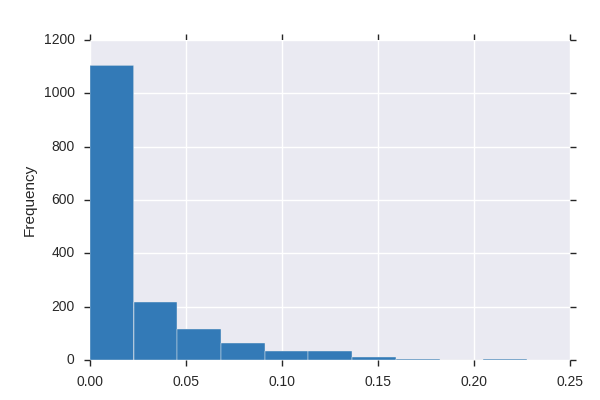

texture28  
Numeric

| Distinct count | 94 |
| --- | --- |
| Unique (%) | 5.9% |
| Missing (%) | 0.0% |
| Missing (n) | 0 |
| Infinite (%) | 0.0% |
| Infinite (n) | 0 |

| Mean | 0.010108 |
| --- | --- |
| Minimum | 0 |
| Maximum | 0.1709 |
| Zeros (%) | 41.5% |

Toggle details

Quantile statistics

| Minimum | 0 |
| --- | --- |
| 5-th percentile | 0 |
| Q1 | 0 |
| Median | 0.001953 |
| Q3 | 0.010742 |
| 95-th percentile | 0.057617 |
| Maximum | 0.1709 |
| Range | 0.1709 |
| Interquartile range | 0.010742 |

Descriptive statistics

| Standard deviation | 0.018827 |
| --- | --- |
| Coef of variation | 1.8626 |
| Kurtosis | 9.6897 |
| Mean | 0.010108 |
| MAD | 0.012225 |
| Skewness | 2.8618 |
| Sum | 16.011 |
| Variance | 0.00035444 |
| Memory size | 12.5 KiB |

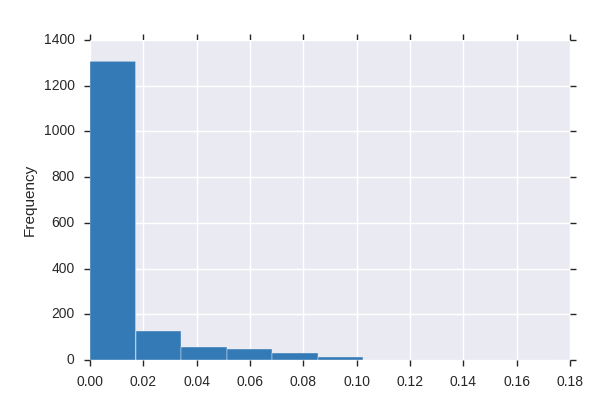

texture29  
Numeric

| Distinct count | 119 |
| --- | --- |
| Unique (%) | 7.5% |
| Missing (%) | 0.0% |
| Missing (n) | 0 |
| Infinite (%) | 0.0% |
| Infinite (n) | 0 |

| Mean | 0.021294 |
| --- | --- |
| Minimum | 0 |
| Maximum | 0.21484 |
| Zeros (%) | 13.0% |

Toggle details

Quantile statistics

| Minimum | 0 |
| --- | --- |
| 5-th percentile | 0 |
| Q1 | 0.003906 |
| Median | 0.012695 |
| Q3 | 0.029541 |
| 95-th percentile | 0.0625 |
| Maximum | 0.21484 |
| Range | 0.21484 |
| Interquartile range | 0.025635 |

Descriptive statistics

| Standard deviation | 0.026097 |
| --- | --- |
| Coef of variation | 1.2256 |
| Kurtosis | 11.014 |
| Mean | 0.021294 |
| MAD | 0.01795 |
| Skewness | 2.7571 |
| Sum | 33.729 |
| Variance | 0.00068105 |
| Memory size | 12.5 KiB |

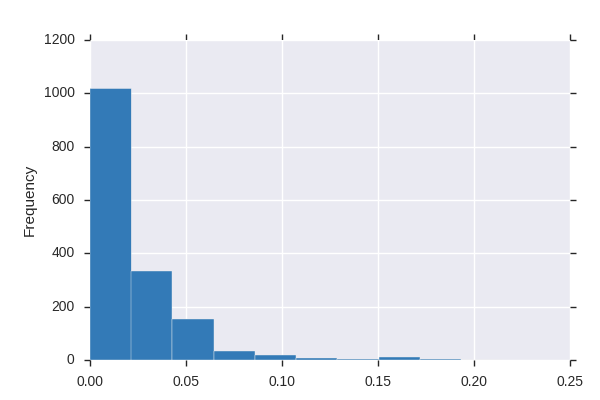

texture3  
Numeric

| Distinct count | 72 |
| --- | --- |
| Unique (%) | 4.5% |
| Missing (%) | 0.0% |
| Missing (n) | 0 |
| Infinite (%) | 0.0% |
| Infinite (n) | 0 |

| Mean | 0.010299 |
| --- | --- |
| Minimum | 0 |
| Maximum | 0.11816 |
| Zeros (%) | 26.4% |

Toggle details

Quantile statistics

| Minimum | 0 |
| --- | --- |
| 5-th percentile | 0 |
| Q1 | 0 |
| Median | 0.005859 |
| Q3 | 0.014648 |
| 95-th percentile | 0.037109 |
| Maximum | 0.11816 |
| Range | 0.11816 |
| Interquartile range | 0.014648 |

Descriptive statistics

| Standard deviation | 0.013468 |
| --- | --- |
| Coef of variation | 1.3077 |
| Kurtosis | 8.7992 |
| Mean | 0.010299 |
| MAD | 0.0095773 |
| Skewness | 2.4084 |
| Sum | 16.313 |
| Variance | 0.00018138 |
| Memory size | 12.5 KiB |

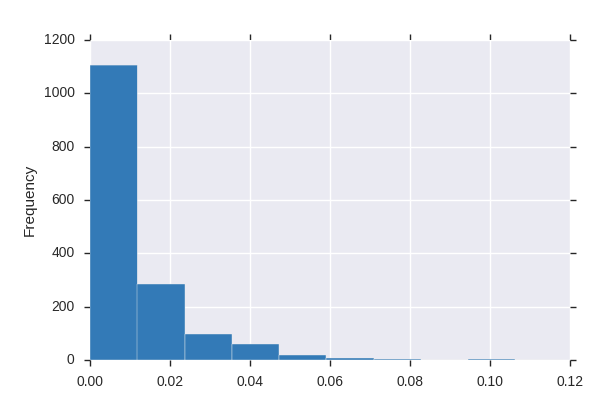

texture30  
Numeric

| Distinct count | 67 |
| --- | --- |
| Unique (%) | 4.2% |
| Missing (%) | 0.0% |
| Missing (n) | 0 |
| Infinite (%) | 0.0% |
| Infinite (n) | 0 |

| Mean | 0.011586 |
| --- | --- |
| Minimum | 0 |
| Maximum | 0.085938 |
| Zeros (%) | 20.6% |

Toggle details

Quantile statistics

| Minimum | 0 |
| --- | --- |
| 5-th percentile | 0 |
| Q1 | 0.000977 |
| Median | 0.007812 |
| Q3 | 0.016846 |
| 95-th percentile | 0.035986 |
| Maximum | 0.085938 |
| Range | 0.085938 |
| Interquartile range | 0.015869 |

Descriptive statistics

| Standard deviation | 0.012622 |
| --- | --- |
| Coef of variation | 1.0894 |
| Kurtosis | 3.3805 |
| Mean | 0.011586 |
| MAD | 0.0096259 |
| Skewness | 1.6266 |
| Sum | 18.353 |
| Variance | 0.00015931 |
| Memory size | 12.5 KiB |

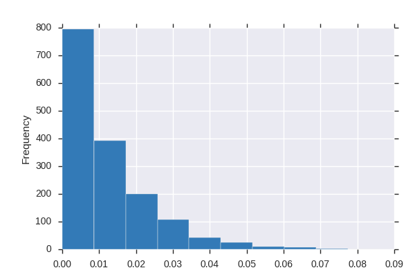

texture31  
Numeric

| Distinct count | 124 |
| --- | --- |
| Unique (%) | 7.8% |
| Missing (%) | 0.0% |
| Missing (n) | 0 |
| Infinite (%) | 0.0% |
| Infinite (n) | 0 |

| Mean | 0.023934 |
| --- | --- |
| Minimum | 0 |
| Maximum | 0.28516 |
| Zeros (%) | 10.2% |

Toggle details

Quantile statistics

| Minimum | 0 |
| --- | --- |
| 5-th percentile | 0 |
| Q1 | 0.004883 |
| Median | 0.015625 |
| Q3 | 0.033203 |
| 95-th percentile | 0.073242 |
| Maximum | 0.28516 |
| Range | 0.28516 |
| Interquartile range | 0.02832 |

Descriptive statistics

| Standard deviation | 0.027705 |
| --- | --- |
| Coef of variation | 1.1575 |
| Kurtosis | 13.256 |
| Mean | 0.023934 |
| MAD | 0.019432 |
| Skewness | 2.7557 |
| Sum | 37.911 |
| Variance | 0.00076754 |
| Memory size | 12.5 KiB |

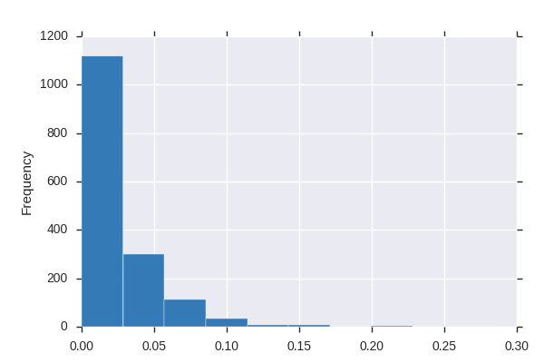

texture32  
Numeric

| Distinct count | 84 |
| --- | --- |
| Unique (%) | 5.3% |
| Missing (%) | 0.0% |
| Missing (n) | 0 |
| Infinite (%) | 0.0% |
| Infinite (n) | 0 |

| Mean | 0.0061794 |
| --- | --- |
| Minimum | 0 |
| Maximum | 0.12891 |
| Zeros (%) | 68.9% |

Toggle details

Quantile statistics

| Minimum | 0 |
| --- | --- |
| 5-th percentile | 0 |
| Q1 | 0 |
| Median | 0 |
| Q3 | 0.00293 |
| 95-th percentile | 0.038086 |
| Maximum | 0.12891 |
| Range | 0.12891 |
| Interquartile range | 0.00293 |

Descriptive statistics

| Standard deviation | 0.015479 |
| --- | --- |
| Coef of variation | 2.505 |
| Kurtosis | 14.742 |
| Mean | 0.0061794 |
| MAD | 0.0092356 |
| Skewness | 3.5616 |
| Sum | 9.7881 |
| Variance | 0.0002396 |
| Memory size | 12.5 KiB |

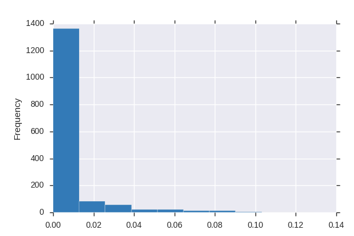

texture33  
Numeric

| Distinct count | 184 |
| --- | --- |
| Unique (%) | 11.6% |
| Missing (%) | 0.0% |
| Missing (n) | 0 |
| Infinite (%) | 0.0% |
| Infinite (n) | 0 |

| Mean | 0.022311 |
| --- | --- |
| Minimum | 0 |
| Maximum | 0.46094 |
| Zeros (%) | 49.9% |

Toggle details

Quantile statistics

| Minimum | 0 |
| --- | --- |
| 5-th percentile | 0 |
| Q1 | 0 |
| Median | 0.000977 |
| Q3 | 0.011719 |
| 95-th percentile | 0.14004 |
| Maximum | 0.46094 |
| Range | 0.46094 |
| Interquartile range | 0.011719 |

Descriptive statistics

| Standard deviation | 0.0568 |
| --- | --- |
| Coef of variation | 2.5459 |
| Kurtosis | 16.157 |
| Mean | 0.022311 |
| MAD | 0.032098 |
| Skewness | 3.7872 |
| Sum | 35.34 |
| Variance | 0.0032263 |
| Memory size | 12.5 KiB |

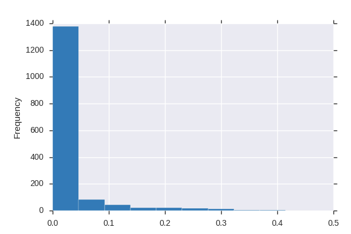

texture34  
Numeric

| Distinct count | 168 |
| --- | --- |
| Unique (%) | 10.6% |
| Missing (%) | 0.0% |
| Missing (n) | 0 |
| Infinite (%) | 0.0% |
| Infinite (n) | 0 |

| Mean | 0.026373 |
| --- | --- |
| Minimum | 0 |
| Maximum | 0.35352 |
| Zeros (%) | 30.2% |

Toggle details

Quantile statistics

| Minimum | 0 |
| --- | --- |
| 5-th percentile | 0 |
| Q1 | 0 |
| Median | 0.010742 |
| Q3 | 0.033447 |
| 95-th percentile | 0.10825 |
| Maximum | 0.35352 |
| Range | 0.35352 |
| Interquartile range | 0.033447 |

Descriptive statistics

| Standard deviation | 0.042228 |
| --- | --- |
| Coef of variation | 1.6012 |
| Kurtosis | 11.924 |
| Mean | 0.026373 |
| MAD | 0.027745 |
| Skewness | 3.0062 |
| Sum | 41.774 |
| Variance | 0.0017832 |
| Memory size | 12.5 KiB |

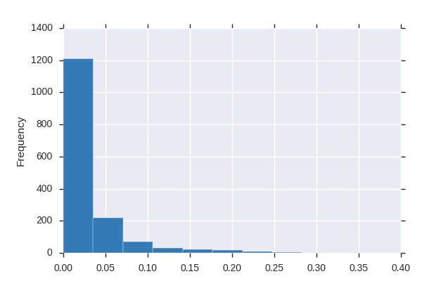

texture35  
Numeric

| Distinct count | 65 |
| --- | --- |
| Unique (%) | 4.1% |
| Missing (%) | 0.0% |
| Missing (n) | 0 |
| Infinite (%) | 0.0% |
| Infinite (n) | 0 |

| Mean | 0.010544 |
| --- | --- |
| Minimum | 0 |
| Maximum | 0.085938 |
| Zeros (%) | 23.2% |

Toggle details

Quantile statistics

| Minimum | 0 |
| --- | --- |
| 5-th percentile | 0 |
| Q1 | 0.000977 |
| Median | 0.006836 |
| Q3 | 0.015625 |
| 95-th percentile | 0.03501 |
| Maximum | 0.085938 |
| Range | 0.085938 |
| Interquartile range | 0.014648 |

Descriptive statistics

| Standard deviation | 0.011912 |
| --- | --- |
| Coef of variation | 1.1298 |
| Kurtosis | 4.2661 |
| Mean | 0.010544 |
| MAD | 0.0089857 |
| Skewness | 1.7608 |
| Sum | 16.701 |
| Variance | 0.00014189 |
| Memory size | 12.5 KiB |

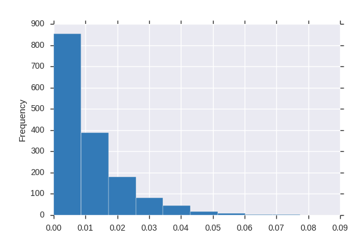

texture36  
Numeric

| Distinct count | 73 |
| --- | --- |
| Unique (%) | 4.6% |
| Missing (%) | 0.0% |
| Missing (n) | 0 |
| Infinite (%) | 0.0% |
| Infinite (n) | 0 |

| Mean | 0.0033656 |
| --- | --- |
| Minimum | 0 |
| Maximum | 0.11523 |
| Zeros (%) | 83.6% |

Toggle details

Quantile statistics

| Minimum | 0 |
| --- | --- |
| 5-th percentile | 0 |
| Q1 | 0 |
| Median | 0 |
| Q3 | 0 |
| 95-th percentile | 0.021484 |
| Maximum | 0.11523 |
| Range | 0.11523 |
| Interquartile range | 0 |

Descriptive statistics

| Standard deviation | 0.012646 |
| --- | --- |
| Coef of variation | 3.7576 |
| Kurtosis | 29.324 |
| Mean | 0.0033656 |
| MAD | 0.0057943 |
| Skewness | 5.1102 |
| Sum | 5.3311 |
| Variance | 0.00015993 |
| Memory size | 12.5 KiB |

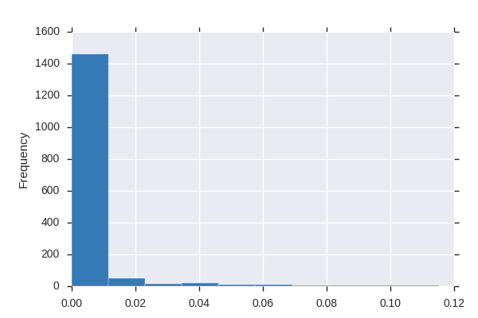

texture37  
Numeric

| Distinct count | 173 |
| --- | --- |
| Unique (%) | 10.9% |
| Missing (%) | 0.0% |
| Missing (n) | 0 |
| Infinite (%) | 0.0% |
| Infinite (n) | 0 |

| Mean | 0.021109 |
| --- | --- |
| Minimum | 0 |
| Maximum | 0.55664 |
| Zeros (%) | 51.9% |

Toggle details

Quantile statistics

| Minimum | 0 |
| --- | --- |
| 5-th percentile | 0 |
| Q1 | 0 |
| Median | 0 |
| Q3 | 0.010742 |
| 95-th percentile | 0.12944 |
| Maximum | 0.55664 |
| Range | 0.55664 |
| Interquartile range | 0.010742 |

Descriptive statistics

| Standard deviation | 0.059073 |
| --- | --- |
| Coef of variation | 2.7985 |
| Kurtosis | 25.449 |
| Mean | 0.021109 |
| MAD | 0.030664 |
| Skewness | 4.618 |
| Sum | 33.437 |
| Variance | 0.0034896 |
| Memory size | 12.5 KiB |

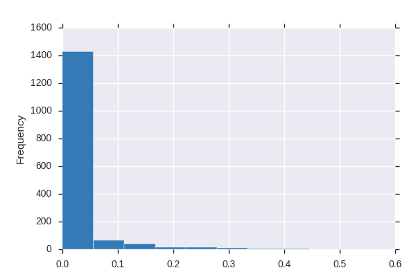

texture38  
Numeric

| Distinct count | 121 |
| --- | --- |
| Unique (%) | 7.6% |
| Missing (%) | 0.0% |
| Missing (n) | 0 |
| Infinite (%) | 0.0% |
| Infinite (n) | 0 |

| Mean | 0.023565 |
| --- | --- |
| Minimum | 0 |
| Maximum | 0.21777 |
| Zeros (%) | 23.6% |

Toggle details

Quantile statistics

| Minimum | 0 |
| --- | --- |
| 5-th percentile | 0 |
| Q1 | 0.000977 |
| Median | 0.016114 |
| Q3 | 0.036133 |
| 95-th percentile | 0.076025 |
| Maximum | 0.21777 |
| Range | 0.21777 |
| Interquartile range | 0.035156 |

Descriptive statistics

| Standard deviation | 0.027179 |
| --- | --- |
| Coef of variation | 1.1534 |
| Kurtosis | 4.924 |
| Mean | 0.023565 |
| MAD | 0.020721 |
| Skewness | 1.8009 |
| Sum | 37.327 |
| Variance | 0.0007387 |
| Memory size | 12.5 KiB |

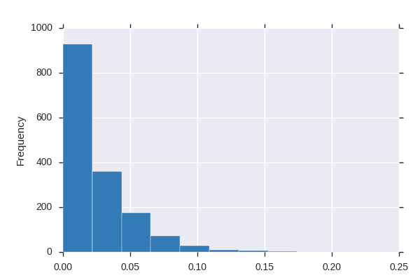

texture39  
Numeric

| Distinct count | 100 |
| --- | --- |
| Unique (%) | 6.3% |
| Missing (%) | 0.0% |
| Missing (n) | 0 |
| Infinite (%) | 0.0% |
| Infinite (n) | 0 |

| Mean | 0.017297 |
| --- | --- |
| Minimum | 0 |
| Maximum | 0.14746 |
| Zeros (%) | 24.2% |

Toggle details

Quantile statistics

| Minimum | 0 |
| --- | --- |
| 5-th percentile | 0 |
| Q1 | 0.000977 |
| Median | 0.008789 |
| Q3 | 0.026367 |
| 95-th percentile | 0.061523 |
| Maximum | 0.14746 |
| Range | 0.14746 |
| Interquartile range | 0.02539 |

Descriptive statistics

| Standard deviation | 0.021531 |
| --- | --- |
| Coef of variation | 1.2448 |
| Kurtosis | 3.2332 |
| Mean | 0.017297 |
| MAD | 0.016582 |
| Skewness | 1.6992 |
| Sum | 27.398 |
| Variance | 0.0004636 |
| Memory size | 12.5 KiB |

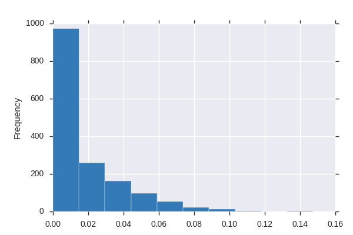

texture4  
Numeric

| Distinct count | 101 |
| --- | --- |
| Unique (%) | 6.4% |
| Missing (%) | 0.0% |
| Missing (n) | 0 |
| Infinite (%) | 0.0% |
| Infinite (n) | 0 |

| Mean | 0.015434 |
| --- | --- |
| Minimum | 0 |
| Maximum | 0.16113 |
| Zeros (%) | 26.7% |

Toggle details

Quantile statistics

| Minimum | 0 |
| --- | --- |
| 5-th percentile | 0 |
| Q1 | 0 |
| Median | 0.005859 |
| Q3 | 0.022461 |
| 95-th percentile | 0.061377 |
| Maximum | 0.16113 |
| Range | 0.16113 |
| Interquartile range | 0.022461 |

Descriptive statistics

| Standard deviation | 0.021683 |
| --- | --- |
| Coef of variation | 1.4049 |
| Kurtosis | 5.1792 |
| Mean | 0.015434 |
| MAD | 0.01588 |
| Skewness | 2.1127 |
| Sum | 24.447 |
| Variance | 0.00047017 |
| Memory size | 12.5 KiB |

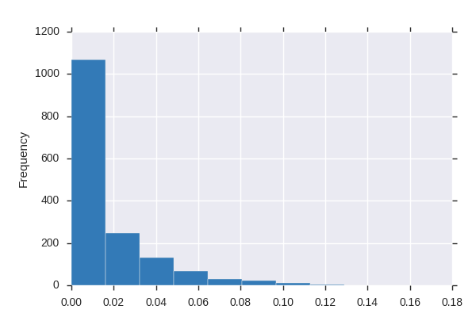

texture40  
Numeric

| Distinct count | 118 |
| --- | --- |
| Unique (%) | 7.4% |
| Missing (%) | 0.0% |
| Missing (n) | 0 |
| Infinite (%) | 0.0% |
| Infinite (n) | 0 |

| Mean | 0.019303 |
| --- | --- |
| Minimum | 0 |
| Maximum | 0.16602 |
| Zeros (%) | 19.3% |

Toggle details

Quantile statistics

| Minimum | 0 |
| --- | --- |
| 5-th percentile | 0 |
| Q1 | 0.001953 |
| Median | 0.009766 |
| Q3 | 0.026367 |
| 95-th percentile | 0.072266 |
| Maximum | 0.16602 |
| Range | 0.16602 |
| Interquartile range | 0.024414 |

Descriptive statistics

| Standard deviation | 0.025736 |
| --- | --- |
| Coef of variation | 1.3333 |
| Kurtosis | 6.4509 |
| Mean | 0.019303 |
| MAD | 0.018329 |
| Skewness | 2.2827 |
| Sum | 30.576 |
| Variance | 0.00066236 |
| Memory size | 12.5 KiB |

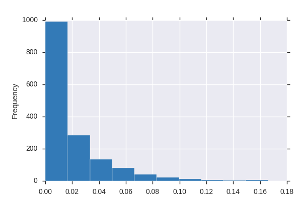

texture41  
Numeric

| Distinct count | 152 |
| --- | --- |
| Unique (%) | 9.6% |
| Missing (%) | 0.0% |
| Missing (n) | 0 |
| Infinite (%) | 0.0% |
| Infinite (n) | 0 |

| Mean | 0.015861 |
| --- | --- |
| Minimum | 0 |
| Maximum | 0.41113 |
| Zeros (%) | 49.9% |

Toggle details

Quantile statistics

| Minimum | 0 |
| --- | --- |
| 5-th percentile | 0 |
| Q1 | 0 |
| Median | 0.000977 |
| Q3 | 0.010742 |
| 95-th percentile | 0.086621 |
| Maximum | 0.41113 |
| Range | 0.41113 |
| Interquartile range | 0.010742 |

Descriptive statistics

| Standard deviation | 0.040574 |
| --- | --- |
| Coef of variation | 2.5581 |
| Kurtosis | 25.1 |
| Mean | 0.015861 |
| MAD | 0.022197 |
| Skewness | 4.4556 |
| Sum | 25.124 |
| Variance | 0.0016463 |
| Memory size | 12.5 KiB |

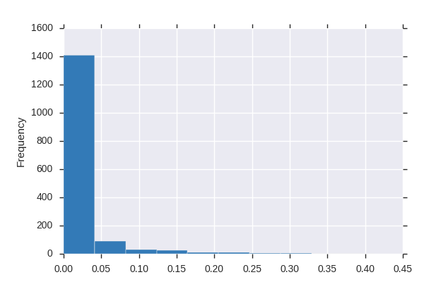

texture42  
Numeric

| Distinct count | 61 |
| --- | --- |
| Unique (%) | 3.9% |
| Missing (%) | 0.0% |
| Missing (n) | 0 |
| Infinite (%) | 0.0% |
| Infinite (n) | 0 |

| Mean | 0.0061183 |
| --- | --- |
| Minimum | 0 |
| Maximum | 0.075195 |
| Zeros (%) | 47.2% |

Toggle details

Quantile statistics

| Minimum | 0 |
| --- | --- |
| 5-th percentile | 0 |
| Q1 | 0 |
| Median | 0.000977 |
| Q3 | 0.006836 |
| 95-th percentile | 0.029297 |
| Maximum | 0.075195 |
| Range | 0.075195 |
| Interquartile range | 0.006836 |

Descriptive statistics

| Standard deviation | 0.011133 |
| --- | --- |
| Coef of variation | 1.8196 |
| Kurtosis | 9.5329 |
| Mean | 0.0061183 |
| MAD | 0.007425 |
| Skewness | 2.8438 |
| Sum | 9.6914 |
| Variance | 0.00012395 |
| Memory size | 12.5 KiB |

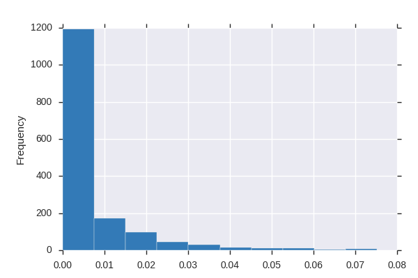

texture43  
Numeric

| Distinct count | 88 |
| --- | --- |
| Unique (%) | 5.6% |
| Missing (%) | 0.0% |
| Missing (n) | 0 |
| Infinite (%) | 0.0% |
| Infinite (n) | 0 |

| Mean | 0.014197 |
| --- | --- |
| Minimum | 0 |
| Maximum | 0.17676 |
| Zeros (%) | 23.0% |

Toggle details

Quantile statistics

| Minimum | 0 |
| --- | --- |
| 5-th percentile | 0 |
| Q1 | 0.000977 |
| Median | 0.007812 |
| Q3 | 0.020508 |
| 95-th percentile | 0.051611 |
| Maximum | 0.17676 |
| Range | 0.17676 |
| Interquartile range | 0.019531 |

Descriptive statistics

| Standard deviation | 0.018121 |
| --- | --- |
| Coef of variation | 1.2764 |
| Kurtosis | 6.9554 |
| Mean | 0.014197 |
| MAD | 0.013348 |
| Skewness | 2.118 |
| Sum | 22.487 |
| Variance | 0.00032837 |
| Memory size | 12.5 KiB |

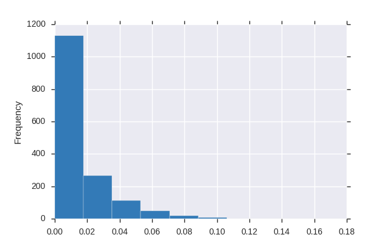

texture44  
Numeric

| Distinct count | 175 |
| --- | --- |
| Unique (%) | 11.0% |
| Missing (%) | 0.0% |
| Missing (n) | 0 |
| Infinite (%) | 0.0% |
| Infinite (n) | 0 |

| Mean | 0.025868 |
| --- | --- |
| Minimum | 0 |
| Maximum | 0.41211 |
| Zeros (%) | 33.0% |

Toggle details

Quantile statistics

| Minimum | 0 |
| --- | --- |
| 5-th percentile | 0 |
| Q1 | 0 |
| Median | 0.005859 |
| Q3 | 0.030517 |
| 95-th percentile | 0.11997 |
| Maximum | 0.41211 |
| Range | 0.41211 |
| Interquartile range | 0.030517 |

Descriptive statistics

| Standard deviation | 0.045204 |
| --- | --- |
| Coef of variation | 1.7475 |
| Kurtosis | 11.851 |
| Mean | 0.025868 |
| MAD | 0.030419 |
| Skewness | 2.9675 |
| Sum | 40.975 |
| Variance | 0.0020434 |
| Memory size | 12.5 KiB |

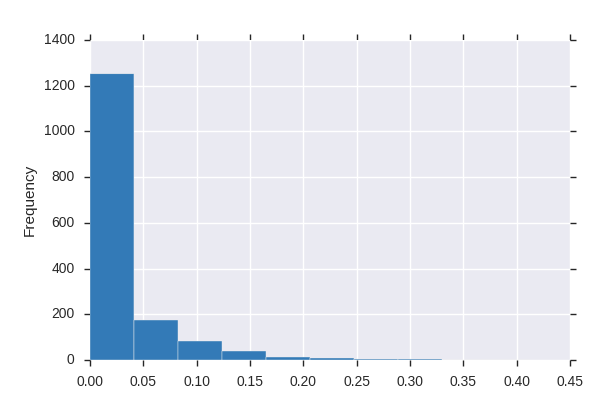

texture45  
Numeric

| Distinct count | 101 |
| --- | --- |
| Unique (%) | 6.4% |
| Missing (%) | 0.0% |
| Missing (n) | 0 |
| Infinite (%) | 0.0% |
| Infinite (n) | 0 |

| Mean | 0.016409 |
| --- | --- |
| Minimum | 0 |
| Maximum | 0.1377 |
| Zeros (%) | 17.8% |

Toggle details

Quantile statistics

| Minimum | 0 |
| --- | --- |
| 5-th percentile | 0 |
| Q1 | 0.000977 |
| Median | 0.007812 |
| Q3 | 0.022461 |
| 95-th percentile | 0.064453 |
| Maximum | 0.1377 |
| Range | 0.1377 |
| Interquartile range | 0.021484 |

Descriptive statistics

| Standard deviation | 0.021646 |
| --- | --- |
| Coef of variation | 1.3191 |
| Kurtosis | 4.2976 |
| Mean | 0.016409 |
| MAD | 0.015896 |
| Skewness | 1.9943 |
| Sum | 25.992 |
| Variance | 0.00046855 |
| Memory size | 12.5 KiB |

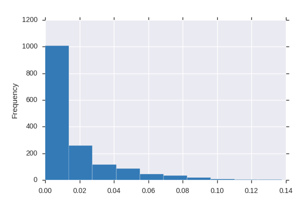

texture46  
Numeric

| Distinct count | 121 |
| --- | --- |
| Unique (%) | 7.6% |
| Missing (%) | 0.0% |
| Missing (n) | 0 |
| Infinite (%) | 0.0% |
| Infinite (n) | 0 |

| Mean | 0.021852 |
| --- | --- |
| Minimum | 0 |
| Maximum | 0.17578 |
| Zeros (%) | 30.1% |

Toggle details

Quantile statistics

| Minimum | 0 |
| --- | --- |
| 5-th percentile | 0 |
| Q1 | 0 |
| Median | 0.010742 |
| Q3 | 0.035156 |
| 95-th percentile | 0.075195 |
| Maximum | 0.17578 |
| Range | 0.17578 |
| Interquartile range | 0.035156 |

Descriptive statistics

| Standard deviation | 0.026452 |
| --- | --- |
| Coef of variation | 1.2105 |
| Kurtosis | 2.4576 |
| Mean | 0.021852 |
| MAD | 0.020967 |
| Skewness | 1.5016 |
| Sum | 34.613 |
| Variance | 0.0006997 |
| Memory size | 12.5 KiB |

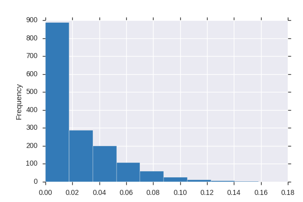

texture47  
Numeric

| Distinct count | 77 |
| --- | --- |
| Unique (%) | 4.9% |
| Missing (%) | 0.0% |
| Missing (n) | 0 |
| Infinite (%) | 0.0% |
| Infinite (n) | 0 |

| Mean | 0.018696 |
| --- | --- |
| Minimum | 0 |
| Maximum | 0.098633 |
| Zeros (%) | 13.1% |

Toggle details

Quantile statistics

| Minimum | 0 |
| --- | --- |
| 5-th percentile | 0 |
| Q1 | 0.004883 |
| Median | 0.015625 |
| Q3 | 0.029297 |
| 95-th percentile | 0.048682 |
| Maximum | 0.098633 |
| Range | 0.098633 |
| Interquartile range | 0.024414 |

Descriptive statistics

| Standard deviation | 0.016148 |
| --- | --- |
| Coef of variation | 0.86367 |
| Kurtosis | 0.96704 |
| Mean | 0.018696 |
| MAD | 0.013142 |
| Skewness | 0.96371 |
| Sum | 29.615 |
| Variance | 0.00026074 |
| Memory size | 12.5 KiB |

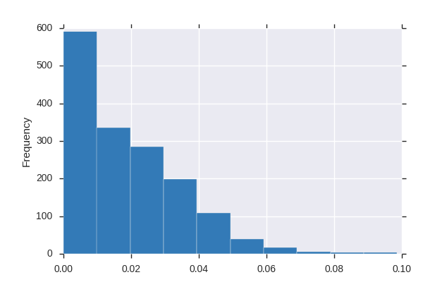

texture48  
Numeric

| Distinct count | 131 |
| --- | --- |
| Unique (%) | 8.3% |
| Missing (%) | 0.0% |
| Missing (n) | 0 |
| Infinite (%) | 0.0% |
| Infinite (n) | 0 |

| Mean | 0.016566 |
| --- | --- |
| Minimum | 0 |
| Maximum | 0.24902 |
| Zeros (%) | 49.6% |

Toggle details

Quantile statistics

| Minimum | 0 |
| --- | --- |
| 5-th percentile | 0 |
| Q1 | 0 |
| Median | 0.000977 |
| Q3 | 0.022461 |
| 95-th percentile | 0.076172 |
| Maximum | 0.24902 |
| Range | 0.24902 |
| Interquartile range | 0.022461 |

Descriptive statistics

| Standard deviation | 0.030121 |
| --- | --- |
| Coef of variation | 1.8183 |
| Kurtosis | 8.3624 |
| Mean | 0.016566 |
| MAD | 0.021403 |
| Skewness | 2.5842 |
| Sum | 26.24 |
| Variance | 0.00090729 |
| Memory size | 12.5 KiB |

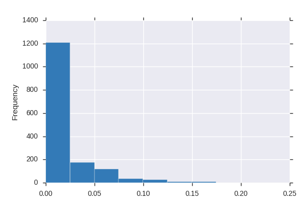

texture49  
Numeric

| Distinct count | 73 |
| --- | --- |
| Unique (%) | 4.6% |
| Missing (%) | 0.0% |
| Missing (n) | 0 |
| Infinite (%) | 0.0% |
| Infinite (n) | 0 |

| Mean | 0.011747 |
| --- | --- |
| Minimum | 0 |
| Maximum | 0.11426 |
| Zeros (%) | 19.8% |

Toggle details

Quantile statistics

| Minimum | 0 |
| --- | --- |
| 5-th percentile | 0 |
| Q1 | 0.000977 |
| Median | 0.007812 |
| Q3 | 0.017578 |
| 95-th percentile | 0.037109 |
| Maximum | 0.11426 |
| Range | 0.11426 |
| Interquartile range | 0.016601 |

Descriptive statistics

| Standard deviation | 0.013488 |
| --- | --- |
| Coef of variation | 1.1482 |
| Kurtosis | 8.9064 |
| Mean | 0.011747 |
| MAD | 0.0097432 |
| Skewness | 2.3033 |
| Sum | 18.607 |
| Variance | 0.00018193 |
| Memory size | 12.5 KiB |

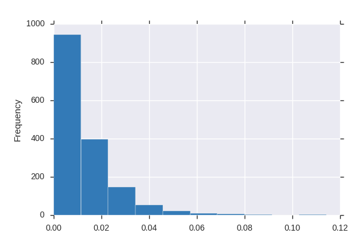

texture5  
Numeric

| Distinct count | 154 |
| --- | --- |
| Unique (%) | 9.7% |
| Missing (%) | 0.0% |
| Missing (n) | 0 |
| Infinite (%) | 0.0% |
| Infinite (n) | 0 |

| Mean | 0.026384 |
| --- | --- |
| Minimum | 0 |
| Maximum | 0.20117 |
| Zeros (%) | 36.9% |

Toggle details

Quantile statistics

| Minimum | 0 |
| --- | --- |
| 5-th percentile | 0 |
| Q1 | 0 |
| Median | 0.005859 |
| Q3 | 0.043945 |
| 95-th percentile | 0.10742 |
| Maximum | 0.20117 |
| Range | 0.20117 |
| Interquartile range | 0.043945 |

Descriptive statistics

| Standard deviation | 0.037642 |
| --- | --- |
| Coef of variation | 1.4267 |
| Kurtosis | 2.1379 |
| Mean | 0.026384 |
| MAD | 0.029676 |
| Skewness | 1.6233 |
| Sum | 41.793 |
| Variance | 0.0014169 |
| Memory size | 12.5 KiB |

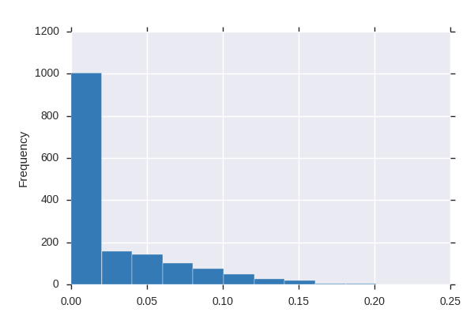

texture50  
Numeric

| Distinct count | 129 |
| --- | --- |
| Unique (%) | 8.1% |
| Missing (%) | 0.0% |
| Missing (n) | 0 |
| Infinite (%) | 0.0% |
| Infinite (n) | 0 |

| Mean | 0.019161 |
| --- | --- |
| Minimum | 0 |
| Maximum | 0.23242 |
| Zeros (%) | 20.6% |

Toggle details

Quantile statistics

| Minimum | 0 |
| --- | --- |
| 5-th percentile | 0 |
| Q1 | 0.001953 |
| Median | 0.009766 |
| Q3 | 0.024414 |
| 95-th percentile | 0.067236 |
| Maximum | 0.23242 |
| Range | 0.23242 |
| Interquartile range | 0.022461 |

Descriptive statistics

| Standard deviation | 0.028362 |
| --- | --- |
| Coef of variation | 1.4802 |
| Kurtosis | 15.052 |
| Mean | 0.019161 |
| MAD | 0.018062 |
| Skewness | 3.3311 |
| Sum | 30.352 |
| Variance | 0.0008044 |
| Memory size | 12.5 KiB |

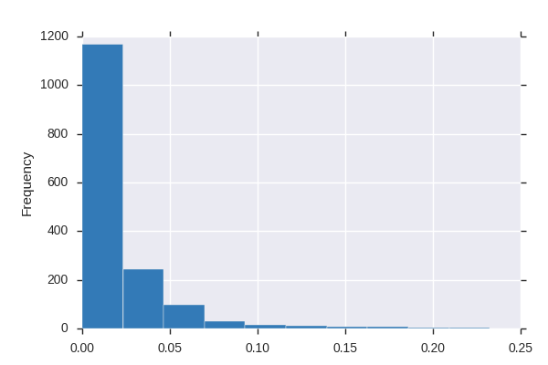

texture51  
Numeric

| Distinct count | 132 |
| --- | --- |
| Unique (%) | 8.3% |
| Missing (%) | 0.0% |
| Missing (n) | 0 |
| Infinite (%) | 0.0% |
| Infinite (n) | 0 |

| Mean | 0.01338 |
| --- | --- |
| Minimum | 0 |
| Maximum | 0.39063 |
| Zeros (%) | 57.5% |

Toggle details

Quantile statistics

| Minimum | 0 |
| --- | --- |
| 5-th percentile | 0 |
| Q1 | 0 |
| Median | 0 |
| Q3 | 0.008789 |
| 95-th percentile | 0.077978 |
| Maximum | 0.39063 |
| Range | 0.39063 |
| Interquartile range | 0.008789 |

Descriptive statistics

| Standard deviation | 0.033126 |
| --- | --- |
| Coef of variation | 2.4758 |
| Kurtosis | 24.136 |
| Mean | 0.01338 |
| MAD | 0.019146 |
| Skewness | 4.2079 |
| Sum | 21.194 |
| Variance | 0.0010973 |
| Memory size | 12.5 KiB |

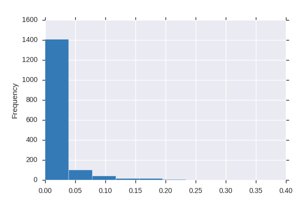

texture52  
Numeric

| Distinct count | 73 |
| --- | --- |
| Unique (%) | 4.6% |
| Missing (%) | 0.0% |
| Missing (n) | 0 |
| Infinite (%) | 0.0% |
| Infinite (n) | 0 |

| Mean | 0.007175 |
| --- | --- |
| Minimum | 0 |
| Maximum | 0.11719 |
| Zeros (%) | 57.5% |

Toggle details

Quantile statistics

| Minimum | 0 |
| --- | --- |
| 5-th percentile | 0 |
| Q1 | 0 |
| Median | 0 |
| Q3 | 0.009766 |
| 95-th percentile | 0.03418 |
| Maximum | 0.11719 |
| Range | 0.11719 |
| Interquartile range | 0.009766 |

Descriptive statistics

| Standard deviation | 0.013612 |
| --- | --- |
| Coef of variation | 1.8972 |
| Kurtosis | 12.464 |
| Mean | 0.007175 |
| MAD | 0.0092957 |
| Skewness | 3.0262 |
| Sum | 11.365 |
| Variance | 0.00018529 |
| Memory size | 12.5 KiB |

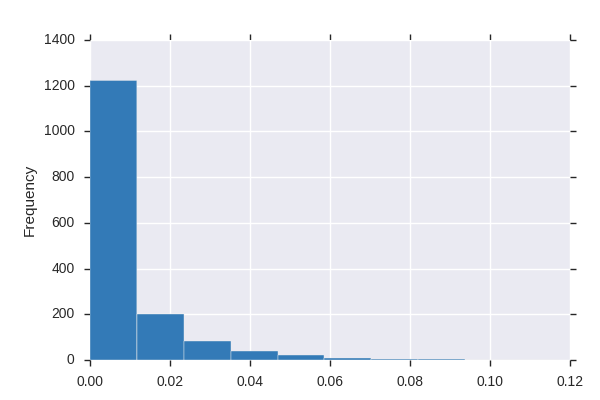

texture53  
Numeric

| Distinct count | 98 |
| --- | --- |
| Unique (%) | 6.2% |
| Missing (%) | 0.0% |
| Missing (n) | 0 |
| Infinite (%) | 0.0% |
| Infinite (n) | 0 |

| Mean | 0.014407 |
| --- | --- |
| Minimum | 0 |
| Maximum | 0.16504 |
| Zeros (%) | 27.0% |

Toggle details

Quantile statistics

| Minimum | 0 |
| --- | --- |
| 5-th percentile | 0 |
| Q1 | 0 |
| Median | 0.004883 |
| Q3 | 0.020508 |
| 95-th percentile | 0.060547 |
| Maximum | 0.16504 |
| Range | 0.16504 |
| Interquartile range | 0.020508 |

Descriptive statistics

| Standard deviation | 0.021208 |
| --- | --- |
| Coef of variation | 1.4721 |
| Kurtosis | 5.966 |
| Mean | 0.014407 |
| MAD | 0.015394 |
| Skewness | 2.2273 |
| Sum | 22.82 |
| Variance | 0.00044976 |
| Memory size | 12.5 KiB |

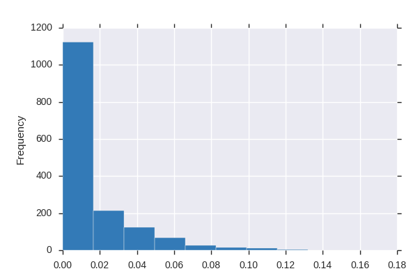

texture54  
Numeric

| Distinct count | 119 |
| --- | --- |
| Unique (%) | 7.5% |
| Missing (%) | 0.0% |
| Missing (n) | 0 |
| Infinite (%) | 0.0% |
| Infinite (n) | 0 |

| Mean | 0.022482 |
| --- | --- |
| Minimum | 0 |
| Maximum | 0.29297 |
| Zeros (%) | 15.3% |

Toggle details

Quantile statistics

| Minimum | 0 |
| --- | --- |
| 5-th percentile | 0 |
| Q1 | 0.00293 |
| Median | 0.012695 |
| Q3 | 0.033203 |
| 95-th percentile | 0.073242 |
| Maximum | 0.29297 |
| Range | 0.29297 |
| Interquartile range | 0.030273 |

Descriptive statistics

| Standard deviation | 0.028109 |
| --- | --- |
| Coef of variation | 1.2503 |
| Kurtosis | 16.74 |
| Mean | 0.022482 |
| MAD | 0.020014 |
| Skewness | 2.958 |
| Sum | 35.611 |
| Variance | 0.00079013 |
| Memory size | 12.5 KiB |

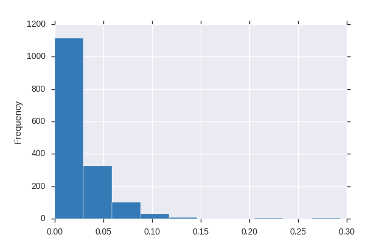

texture55  
Numeric

| Distinct count | 221 |
| --- | --- |
| Unique (%) | 14.0% |
| Missing (%) | 0.0% |
| Missing (n) | 0 |
| Infinite (%) | 0.0% |
| Infinite (n) | 0 |

| Mean | 0.036047 |
| --- | --- |
| Minimum | 0 |
| Maximum | 0.42969 |
| Zeros (%) | 40.5% |

Toggle details

Quantile statistics

| Minimum | 0 |
| --- | --- |
| 5-th percentile | 0 |
| Q1 | 0 |
| Median | 0.003906 |
| Q3 | 0.04126 |
| 95-th percentile | 0.17842 |
| Maximum | 0.42969 |
| Range | 0.42969 |
| Interquartile range | 0.04126 |

Descriptive statistics

| Standard deviation | 0.063792 |
| --- | --- |
| Coef of variation | 1.7697 |
| Kurtosis | 6.6043 |
| Mean | 0.036047 |
| MAD | 0.044401 |
| Skewness | 2.4728 |
| Sum | 57.099 |
| Variance | 0.0040695 |
| Memory size | 12.5 KiB |

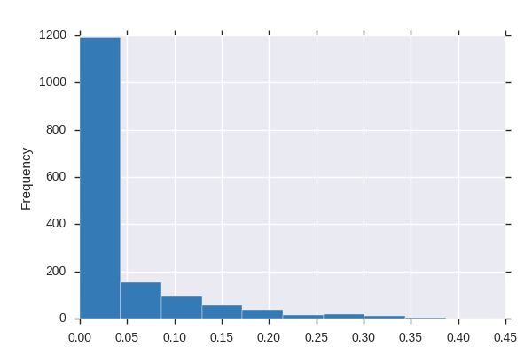

texture56  
Numeric

| Distinct count | 91 |
| --- | --- |
| Unique (%) | 5.7% |
| Missing (%) | 0.0% |
| Missing (n) | 0 |
| Infinite (%) | 0.0% |
| Infinite (n) | 0 |

| Mean | 0.0053612 |
| --- | --- |
| Minimum | 0 |
| Maximum | 0.44141 |
| Zeros (%) | 77.9% |

Toggle details

Quantile statistics

| Minimum | 0 |
| --- | --- |
| 5-th percentile | 0 |
| Q1 | 0 |
| Median | 0 |
| Q3 | 0 |
| 95-th percentile | 0.032227 |
| Maximum | 0.44141 |
| Range | 0.44141 |
| Interquartile range | 0 |

Descriptive statistics

| Standard deviation | 0.022476 |
| --- | --- |
| Coef of variation | 4.1923 |
| Kurtosis | 118.43 |
| Mean | 0.0053612 |
| MAD | 0.0089186 |
| Skewness | 8.8589 |
| Sum | 8.4922 |
| Variance | 0.00050518 |
| Memory size | 12.5 KiB |

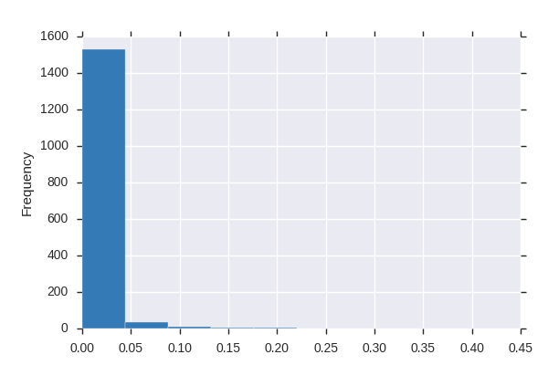

texture57  
Numeric

| Distinct count | 109 |
| --- | --- |
| Unique (%) | 6.9% |
| Missing (%) | 0.0% |
| Missing (n) | 0 |
| Infinite (%) | 0.0% |
| Infinite (n) | 0 |

| Mean | 0.015602 |
| --- | --- |
| Minimum | 0 |
| Maximum | 0.17285 |
| Zeros (%) | 23.5% |

Toggle details

Quantile statistics

| Minimum | 0 |
| --- | --- |
| 5-th percentile | 0 |
| Q1 | 0.000977 |
| Median | 0.005859 |
| Q3 | 0.020508 |
| 95-th percentile | 0.063477 |
| Maximum | 0.17285 |
| Range | 0.17285 |
| Interquartile range | 0.019531 |

Descriptive statistics

| Standard deviation | 0.02288 |
| --- | --- |
| Coef of variation | 1.4664 |
| Kurtosis | 7.4467 |
| Mean | 0.015602 |
| MAD | 0.016364 |
| Skewness | 2.3966 |
| Sum | 24.714 |
| Variance | 0.00052348 |
| Memory size | 12.5 KiB |

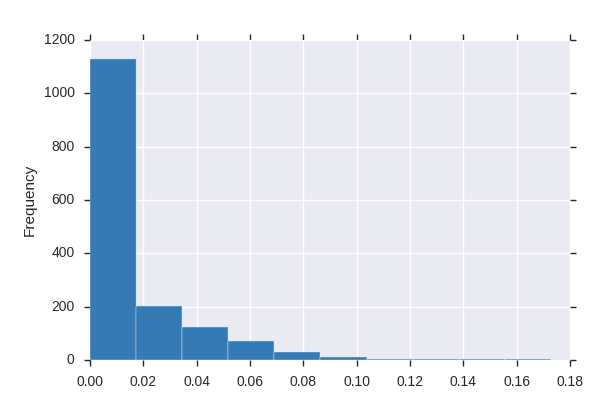

texture58  
Numeric

| Distinct count | 116 |
| --- | --- |
| Unique (%) | 7.3% |
| Missing (%) | 0.0% |
| Missing (n) | 0 |
| Infinite (%) | 0.0% |
| Infinite (n) | 0 |

| Mean | 0.011652 |
| --- | --- |
| Minimum | 0 |
| Maximum | 0.2002 |
| Zeros (%) | 41.9% |

Toggle details